# Project Write Up 2

## Natalie Avila

### 4/30/25

### Introduction

Link : https://www.kaggle.com/datasets/tjkyner/bachelor-degree-majors-by-age-sex-and-state

Description:

- This dataset contains information on 2019 bachelor’s degree recipients in the U.S., showing how many students majored in fields like Science and Engineering, Education, and Arts/Humanities, broken down by gender, age group, and state.

Key Variables:

- State – U.S. state where degrees were awarded
- Sex – Male or Female
- Science and Engineering – Number of degrees in STEM fields
- Education, Arts, Humanities, Business – Number of degrees in non-STEM fields

Basic Summary Statistics:

```python
import pandas as pd
import matplotlib.pyplot as plt
import seaborn as sns
degrees = pd.read_csv("downloads/Bachelor_Degree_Majors.csv")
```

```python
degrees['Science and Engineering'] = degrees['Science and Engineering'].replace({',': ''}, regex=True).astype(float)
degrees['Education'] = degrees['Education'].replace({',': ''}, regex=True).astype(float)
degrees['Arts, Humanities and Others'] = degrees['Arts, Humanities and Others'].replace({',': ''}, regex=True).astype(float)
degrees['Science and Engineering Related Fields'] = degrees['Science and Engineering Related Fields'].replace({',': ''}, regex=True).astype(float)
degrees['Business'] = degrees['Business'].replace({',': ''}, regex=True).astype(float)
pd.options.display.float_format = '{:,.0f}'.format
degrees.head()
```

|  | State | Sex | Age Group | Bachelor's Degree Holders | Science and Engineering | Science and Engineering Related Fields | Business | Education | Arts, Humanities and Others |
| --- | --- | --- | --- | --- | --- | --- | --- | --- | --- |
| 0 | Alabama | Total | 25 and older | 885,357 | 263,555 | 98,445 | 210,147 | 141,071 | 172,139 |
| 1 | Alabama | Total | 25 to 39 | 268,924 | 90,736 | 32,378 | 58,515 | 29,342 | 57,953 |
| 2 | Alabama | Total | 40 to 64 | 418,480 | 115,762 | 46,724 | 112,271 | 63,875 | 79,848 |
| 3 | Alabama | Total | 65 and older | 197,953 | 57,057 | 19,343 | 39,361 | 47,854 | 34,338 |
| 4 | Alabama | Male | 25 and older | 405,618 | 159,366 | 26,004 | 113,909 | 29,490 | 76,849 |

```python
degrees.describe()
```

|  | Science and Engineering | Science and Engineering Related Fields | Business | Education | Arts, Humanities and Others |
| --- | --- | --- | --- | --- | --- |
| count | 612 | 612 | 612 | 612 | 612 |
| mean | 172,368 | 47,789 | 98,567 | 57,189 | 111,026 |
| std | 302,349 | 75,851 | 162,641 | 83,837 | 189,965 |
| min | 1,629 | 623 | 959 | 461 | 1,573 |
| 25% | 29,426 | 8,619 | 14,849 | 10,802 | 19,912 |
| 50% | 73,765 | 21,998 | 41,940 | 28,837 | 49,552 |
| 75% | 184,242 | 51,602 | 114,868 | 65,961 | 119,250 |
| max | 3,929,561 | 781,396 | 1,721,094 | 686,845 | 2,416,067 |

```python
degrees.info()
```

```
<class 'pandas.core.frame.DataFrame'>
RangeIndex: 612 entries, 0 to 611
Data columns (total 9 columns):
 #   Column                                  Non-Null Count  Dtype
---  ------                                  --------------  -----
 0   State                                   612 non-null    object
 1   Sex                                     612 non-null    object
 2   Age Group                               612 non-null    object
 3   Bachelor's Degree Holders               612 non-null    object
 4   Science and Engineering                 612 non-null    float64
 5   Science and Engineering Related Fields  612 non-null    float64
 6   Business                                612 non-null    float64
 7   Education                               612 non-null    float64
 8   Arts, Humanities and Others             612 non-null    float64
dtypes: float64(5), object(4)
memory usage: 43.2+ KB
```

Filters or Modifications:

- Before starting the analysis, I cleaned and prepared the dataset to make sure everything was accurate and ready for modeling. I removed commas from numeric columns like Science and Engineering, Education, Business, and Arts, Humanities and Others so that the values could be properly converted from strings to numbers. I also created a new column called "Non-S&E" by combining the values from Business, Education, and Arts, Humanities and Others. This helped represent all non science degree fields in a single variable. To focus on gender specific trends, I filtered out any rows where the sex was listed as "Total," keeping only male and female entries. For the logistic regression model, I converted the "Sex" column into binary values in which I used 0 for Male and 1 for Female, so that the model could make categorical predictions.

```python
degrees_plot = degrees[['State', 'Sex', 'Science and Engineering']].copy()
degrees_plot['Non-S&E'] = degrees['Business'] + degrees['Education'] + degrees['Arts, Humanities and Others']
```

```python
filtered_df = degrees_plot[degrees_plot["Sex"] != "Total"]
```

### Hypothesis generation and exploration

Question 1:

- Is the gender gap larger in STEM than in non-STEM fields?

Plot:

- Bar Chart

Variables:

- State: Represents specific U.S. states and their corresponding degree data.
- Science and Engineering: number of degrees earned in Science and Engineering fields
- Non-S&E (Non Science and Engineering Degrees): A new category I created to group all degrees earned outside of Science and Engineering fields.
- Sex: Indicates the gender of the degree holders.
- filtered_df: I filtered the rows that were labeled as "Total" on the column of "Sex" so that I could focus only on female and male data.

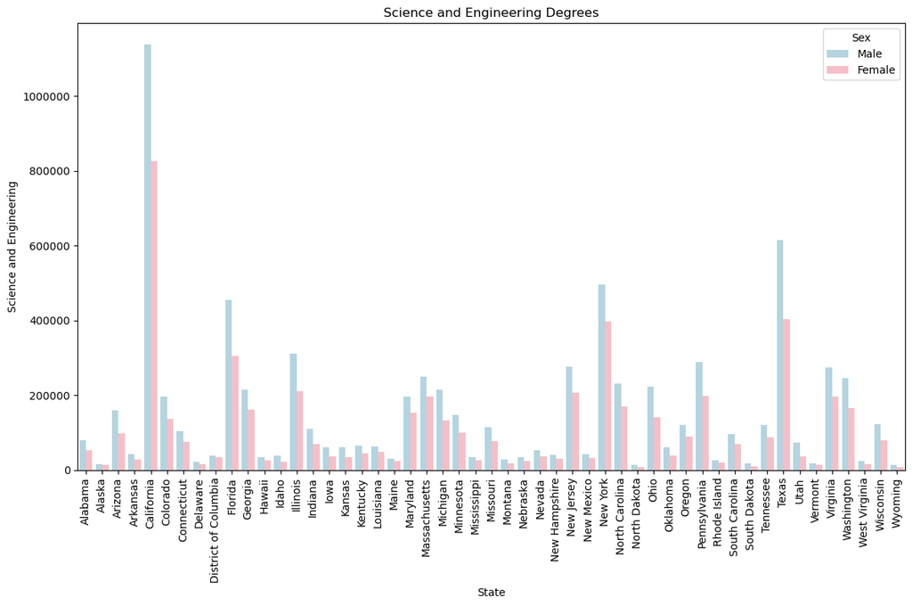

```python
plt.figure(figsize=(12, 8))
sns.barplot(data=filtered_df, x='State', y='Science and Engineering', hue='Sex', palette = ["lightblue", "lightpink"],errorbar=None)
plt.ticklabel_format(style='plain', axis='y')
plt.title("Science and Engineering Degrees")
plt.xticks(rotation=90)
plt.tight_layout()
plt.show()
```

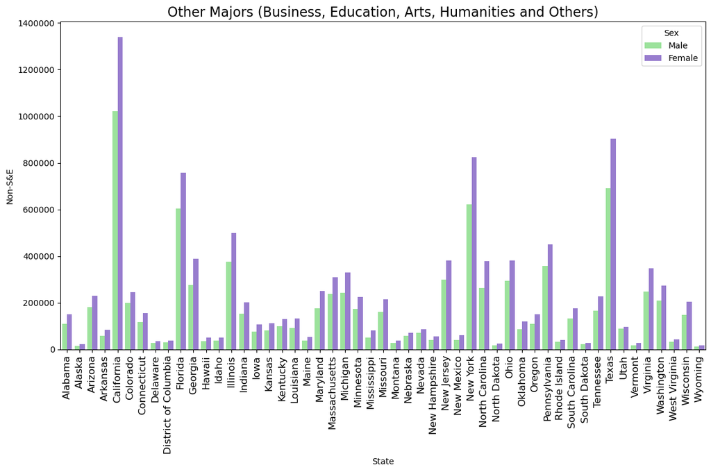

```python
plt.figure(figsize=(12, 8))
sns.barplot(data=filtered_df, x='State', y='Non-S&E', hue='Sex',palette=["lightgreen", "mediumpurple"],errorbar=None)
plt.ticklabel_format(style='plain', axis='y')
plt.title("Other Majors (Business, Education, Arts, Humanities and Others)", fontsize=16)
plt.xticks(rotation=90, fontsize=12)
plt.tight_layout()
plt.show()
```

Question 2:

- How do STEM gender gaps vary by state?

Interpretation:

- STEM gender gaps vary across states, with some states showing a larger difference between male and female participation, while others have smaller gaps or more gender balance. For example, California has the largest gap in Science & Engineering, with about 1.2 million more male degree holders, while Alaska has the smallest gap, with fewer than 10,000 more male degree holders.

Plot:

- Bar Chart

Variables:

- filtered_df: I filtered the rows that were labeled as "Total" on the column of "Sex" so that I could focus only on female and male data.
- pivot_df: This organizes the Science and Engineering degree counts by State and gender, showing totals for males and females.
- Gap: A new column created to calculate the difference between male and female degree holders in each state.

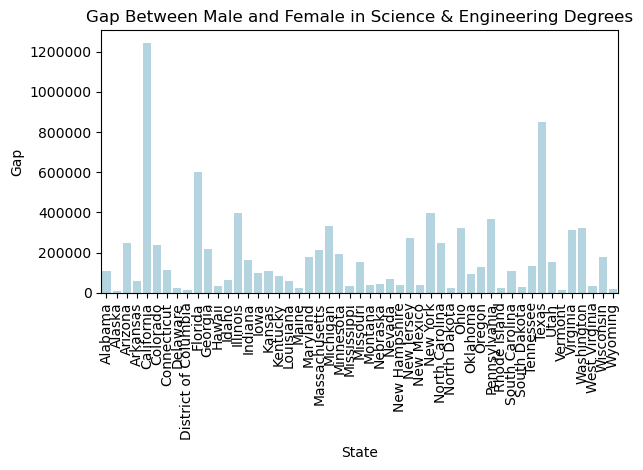

```python
pivot_df = filtered_df.pivot_table(index='State', columns='Sex', values='Science and Engineering', aggfunc='sum')
pivot_df['Gap'] = pivot_df['Male'] - pivot_df['Female']

sns.barplot(x=pivot_df.index, y=pivot_df['Gap'], color='lightblue', errorbar=None)
plt.title("Gap Between Male and Female in Science & Engineering Degrees")
plt.xticks(rotation=90)
plt.ticklabel_format(style='plain', axis='y')
plt.tight_layout()
plt.show()
```

### Machine Learning

Model Choice for quantitative variable :

- Ridge Regression

Independent Variable:

- Science and Engineering: This is the number of Science and Engineering degrees awarded, regardless of gender. Including this helps the model understand how overall participation in S&E fields might relate to the size of the gender gap.
- Non-S&E: This variable accounts for degrees in fields outside Science and Engineering. It may capture differences in interest or opportunities between genders in other academic areas and can help the model identify trends where a high number of Non S&E degrees correlates with gender imbalances in Science and Engineering.
- State: The state in which the data is measured, which is treated as a categorical variable.

Dependent Variable:

- Gap_S&E: This represents the gender gap in Science and Engineering bachelor’s degrees by U.S. state. It is calculated by subtracting the number of female degrees from the number of male degrees in each state. A higher value indicates a larger gap favoring males, while a lower or negative value indicates a smaller or reversed gap. This variable is what the model aims to predict.

Interpretation:

- The model has a high R² score of 0.967 and a relatively low RMSE of 42,029, which suggests that it does a good job at predicting the gender gap in Science and Engineering degrees. This indicates that the model captures most of the variability in the target variable and is effective for this task. Since Ridge regression includes regularization, it helps prevent overfitting by penalizing overly complex models. The high R² and low RMSE together suggest that the model is not underfitting either. Given these strong performance metrics, I'd recommend this model to be used for future predictions.

```python
import math
from sklearn import linear_model, metrics, model_selection
import pandas as pd
```

```python
pivot_df = filtered_df.pivot_table(index='State', columns='Sex', values='Science and Engineering', aggfunc='sum')
pivot_df['Gap_S&E'] = pivot_df['Male'] - pivot_df['Female']

y = pivot_df['Gap_S&E']
X = filtered_df[['Science and Engineering', 'Non-S&E', 'State']]

X = X[X['State'].isin(pivot_df.index)]
y = y.loc[X['State']]

X = pd.get_dummies(X, drop_first=True)

X_train, X_test, y_train, y_test = model_selection.train_test_split(X, y, test_size=0.2, random_state=123)

ridge_model = linear_model.Ridge(alpha=1.0)

ridge_model.fit(X_train, y_train)

y_pred = ridge_model.predict(X_test)

mse = metrics.mean_squared_error(y_test, y_pred)
rmse = math.sqrt(mse)
r2 = metrics.r2_score(y_test, y_pred)

print("RMSE:", rmse)
print("MSE:", mse)
print("R²:", r2)
```

```
RMSE: 42029.99333695882
MSE: 1766520339.9048026
R²: 0.9669123249080751
```

Model Choice for Categorical variable:

- Logistic Regression

Independent Variable:

- Science and Engineering: This represents the number of Science and Engineering degrees earned. Including this variable allows the model to assess how involvement in S&E fields relates to gender, potentially capturing trends where one gender is more represented in these disciplines.
- Non-S&E: This variable tracks the number of degrees earned in non Science and Engineering fields. It provides insight into gender representation in alternative academic areas and helps the model identify whether a preference for or against these fields correlates with gender.

Dependent Variable:

- Sex: This is the gender of the individual, where 0 stands for male and 1 stands for female. The model’s goal is to predict someone's gender based on their degree focus. By doing this, it tries to find patterns in how men and women differ in their academic choices.

Interpretation:

- The logistic regression model performs well, with about 91% accuracy on the training data and nearly 87% accuracy on the test data. This means it does a good job at learning patterns without overfitting, and it still makes accurate predictions on new, unseen data. Looking at the confusion matrix, the model correctly identifies most males (38) and most females (33). It does make a few mistakes, predicting 3 males as females and 8 females as males, but overall it gets most predictions right. These results show that just knowing how degrees are distributed between science & engineering and other fields gives the model enough information to make pretty accurate guesses about gender. So, logistic regression turns out to be a solid choice for this task and could be a good starting point for any analysis involving gender and academic choices.

```python
from sklearn import model_selection, linear_model, metrics
import pandas as pd
import numpy as np

logistic_df = filtered_df.copy()
logistic_df['Sex'] = logistic_df['Sex'].map({'Male': 0, 'Female': 1})

X = logistic_df[['Science and Engineering', 'Non-S&E']]
y = logistic_df[['Sex']]

X_train, X_test, y_train, y_test = model_selection.train_test_split(X, y, test_size=0.2, random_state=111)

reg = linear_model.LogisticRegression(max_iter=1000).fit(X_train, y_train.values.ravel())

print("Train Score:", reg.score(X_train, y_train))
print("Test Score:", reg.score(X_test, y_test))

y_pred = reg.predict(X_test)
print("Accuracy Score:", metrics.accuracy_score(y_test, y_pred))

labels = np.unique(y_test)
cm = metrics.confusion_matrix(y_test, y_pred, labels=labels)
print(pd.DataFrame(cm, index=labels, columns=labels))
```

```
Train Score: 0.9079754601226994
Test Score: 0.8658536585365854
Accuracy Score: 0.8658536585365854
    0   1
0  38   3
1   8  33
```

### Ethical Considerations

I didn’t find any major ethical issues. The information is presented in a way that protects people’s privacy, as it is aggregated by gender, age, and state, with no names or personal identifiers, so no individual data is exposed.

- In terms of respect for persons, the dataset treats individuals anonymously and because there are no names or specific identities are involved, there’s no risk of exposing anyone’s private data.
- Under beneficence, the data is useful for spotting patterns like differences in degree attainment by gender or age. Which can help guide further analysis or inform discussions around equity in education. As long as it’s used carefully and interpreted responsibly, it supports the goal of using data for good.
- For justice, the dataset seems to fairly represent a range of populations by including different genders, age groups, and states. While it doesn't directly address causes of disparity, it allows for examining trends without bias in the data itself.
- Finally, from the perspective of respect for law and public interest, this dataset is publicly available and appears to comply with ethical and legal standards. Since it's based on national education statistics, using it to understand educational outcomes aligns with serving the public good.

### Conclusion

The analysis revealed clear gender gaps in Science and Engineering degrees across U.S. states, with men earning more degrees than women in most cases. This gap was not only noticeable but also measurable and predictable using factors like major type and state, as demonstrated by both regression and classification models. The ridge regression model, with an R² of about 0.97, and the logistic regression model, with approximately 87 percent accuracy, both showed strong predictive performance. This indicates that the gender disparity in STEM fields is likely driven by underlying systemic factors rather than random variation. Looking ahead, it is important not just to identify these gaps but also to promote solutions. Programs that support gender inclusion in STEM, mentorship opportunities, and early exposure to science education can help create a more balanced future.